# Correlation Analysis

Marc Los Huertos

EA030 · Compiled 2026-04-09

EA030 — Basic Statistics — Module 07

# Correlation Analysis

**Prof. Marc Los Huertos** • Pomona College

← Back to Index

The Concept Pearson’s r Spearman’s ρ Pearson vs Spearman Scatterplot Matrices Correlation Structure Misconceptions Reporting

> **What this module covers.** Correlation analysis quantifies the strength and direction of the association between two continuous variables. This module develops both Pearson’s r and Spearman’s ρ from the ground up — the geometry of r, the rank transformation behind ρ, assumption checking, scatterplot matrices for multi-variable datasets, and the systematic pitfalls that make correlation one of the most commonly misinterpreted tools in environmental science.

## 1. The Concept of Correlation

Two continuous variables are **correlated** when they tend to move together — high values of one co-occur with high (or low) values of the other. Correlation is symmetric: the correlation of X with Y is identical to the correlation of Y with X.

A correlation coefficient distils a scattercloud into a single number on the interval [−1, 1]:

r = −1  
perfect  
negative

strong  
negative

weak  
negative

0

weak  
positive

strong  
positive

r = +1  
perfect  
positive

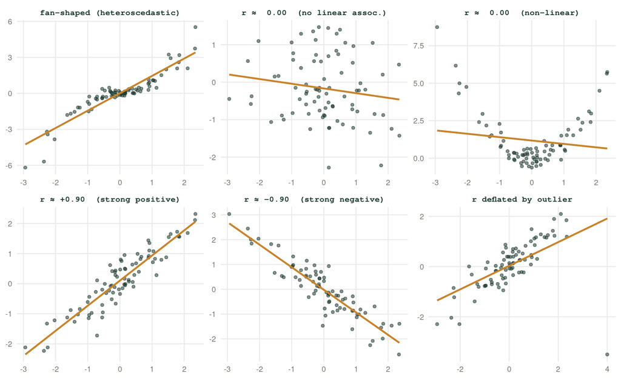

## 2. Pearson’s r — The Linear Correlation Coefficient

Pearson’s r measures the strength and direction of the **linear** association between two continuous variables. Geometrically, it is the cosine of the angle between the two mean-centred variable vectors in n-dimensional space.

$$r = \frac{\sum_{i=1}^{n}(x_i -
\bar{x})(y_i - \bar{y})}
{\sqrt{\sum(x_i-\bar{x})^2}\;\sqrt{\sum(y_i-\bar{y})^2}}
= \frac{S_{xy}}{\sqrt{S_{xx}\,S_{yy}}}$$

$r$ is bounded strictly to [−1, 1]. It equals ±1 only when all points fall exactly on a line.

### The hypothesis test

Testing whether r differs from zero uses a t-transformation:

$$t = \frac{r\sqrt{n-2}}{\sqrt{1-r^2}},
\quad df = n-2$$

H₀ — Null

The population correlation ρ = 0: no linear association exists between X and Y.

H₁ — Alternative

ρ ≠ 0 (two-tailed); or ρ > 0 / ρ < 0 for a directional prediction.

### Assumptions

| Assumption | Consequence if violated | How to check |
| --- | --- | --- |
| Both variables continuous | r is undefined / meaningless | Measurement scale |
| Linear relationship | r understates true association | Scatterplot |
| Bivariate normality (approx.) | t-test p-value unreliable | QQ plots; Shapiro-Wilk |
| No severe outliers | r can be inflated or deflated by a single point | Scatterplot; influence statistics |
| Independent observations | Standard errors wrong | Study design |

**⚠️ Outliers can dominate r**

A single extreme point can shift r from near zero to ±0.6. Always plot your data before computing. If one point is driving the result, report r with and without the outlier and investigate its origin — measurement error, data-entry mistake, or a genuinely extreme but valid observation all call for different responses.

### R walkthrough — water quality dataset

We use a simulated dataset of 55 lake monitoring sites, measuring five water chemistry variables collected during summer stratification: surface temperature (°C), dissolved oxygen (mg/L), pH, total phosphorus (μg/L), and chlorophyll-a (μg/L).

```r
set.seed(314)
n <- 55

temp_C  <- round(rnorm(n, 22, 3.2), 1)
do_mgl  <- round(11.2 - 0.29 * temp_C + rnorm(n, 0, 0.7), 2)
pH      <- round(7.4  + 0.04 * temp_C  + rnorm(n, 0, 0.25), 2)
tp_ugl  <- round(exp(2.8 - 0.07 * do_mgl + rnorm(n, 0, 0.45)), 1)
chla    <- round(exp(0.9 + 0.018 * tp_ugl + rnorm(n, 0, 0.5)), 2)

lakes <- data.frame(temp_C, do_mgl, pH, tp_ugl, chla)
head(lakes, 5)
```

```
##   temp_C do_mgl   pH tp_ugl chla
## 1   17.9   5.00 8.19   12.6 5.93
## 2   24.3   3.91 7.97    7.4 3.13
## 3   19.3   6.49 8.17   18.3 3.22
## 4   19.7   5.88 8.20   17.1 2.17
## 5   22.4   4.39 8.41   12.7 3.87
```

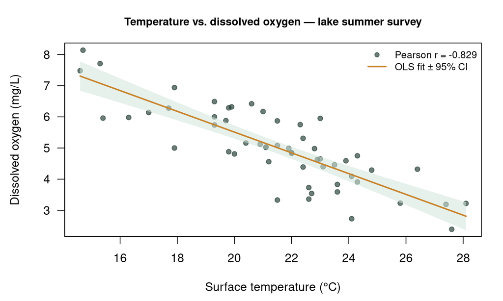

Surface temperature vs. dissolved oxygen at 55 lake monitoring sites. The amber line is the OLS regression line (shown for orientation); the shaded band is a 95% confidence interval around the mean. The negative relationship reflects the physical constraint that warmer water holds less dissolved gas.

```r
par(mar = c(4.5, 4.5, 3, 1.5), las = 1)

plot(lakes$temp_C, lakes$do_mgl,
     pch = 19, cex = 0.9,
     col = adjustcolor("#1e3a2f", 0.65),
     xlab = "Surface temperature (°C)",
     ylab = "Dissolved oxygen (mg/L)",
     main = "Temperature vs. dissolved oxygen — lake summer survey",
     cex.main = 0.91)

fit_td  <- lm(do_mgl ~ temp_C, data = lakes)
xseq    <- seq(min(lakes$temp_C), max(lakes$temp_C), length.out = 200)
ci      <- predict(fit_td, data.frame(temp_C = xseq), interval = "confidence")
polygon(c(xseq, rev(xseq)), c(ci[,"lwr"], rev(ci[,"upr"])),
        col = adjustcolor("#d4e6da", 0.55), border = NA)
lines(xseq, ci[,"fit"], col = "#c8832a", lwd = 2)

r_td <- cor(lakes$temp_C, lakes$do_mgl)
legend("topright",
       legend = c(sprintf("Pearson r = %.3f", r_td), "OLS fit ± 95% CI"),
       lty = c(NA, 1), pch = c(19, NA),
       col = c(adjustcolor("#1e3a2f", .65), "#c8832a"),
       lwd = c(NA, 2), bty = "n", cex = 0.82)
```

```r
cor.test(lakes$temp_C, lakes$do_mgl, method = "pearson")
```

```
##
##  Pearson's product-moment correlation
##
## data:  lakes$temp_C and lakes$do_mgl
## t = -10.78, df = 53, p-value = 5.705e-15
## alternative hypothesis: true correlation is not equal to 0
## 95 percent confidence interval:
##  -0.8968369 -0.7221960
## sample estimates:
##        cor
## -0.8287144
```

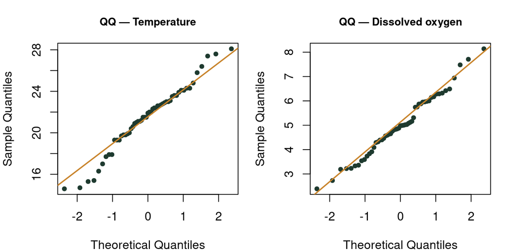

Shapiro-Wilk test results and QQ plots confirm that both variables are approximately normally distributed, satisfying the key assumption for Pearson’s test.

```r
par(mfrow = c(1, 2), mar = c(4, 4, 3, 1))
qqnorm(lakes$temp_C, main = "QQ — Temperature",
       col = "#1e3a2f", pch = 19, cex = 0.75, cex.main = 0.88)
qqline(lakes$temp_C, col = "#c8832a", lwd = 1.8)
qqnorm(lakes$do_mgl, main = "QQ — Dissolved oxygen",
       col = "#1e3a2f", pch = 19, cex = 0.75, cex.main = 0.88)
qqline(lakes$do_mgl, col = "#c8832a", lwd = 1.8)
```

```r
par(mfrow = c(1,1))

shapiro.test(lakes$temp_C)
```

```
##
##  Shapiro-Wilk normality test
##
## data:  lakes$temp_C
## W = 0.97368, p-value = 0.2678
```

```r
shapiro.test(lakes$do_mgl)
```

```
##
##  Shapiro-Wilk normality test
##
## data:  lakes$do_mgl
## W = 0.98431, p-value = 0.688
```

### Confidence interval for r

R reports a 95% CI for ρ using Fisher’s z-transformation, which stabilises the variance of r across its range. The transformation is:

$$z = \tanh^{-1}(r) =
\frac{1}{2}\ln\!\left(\frac{1+r}{1-r}\right),
\quad \text{SE}(z) = \frac{1}{\sqrt{n-3}}$$

The CI is computed on the z scale and back-transformed to r. This CI is reported automatically by `cor.test()` in the output above.

**⚙️ Computing r by hand (to build intuition)**

```
z_x  <- scale(lakes$temp_C)   # (x - x̄) / sd(x)
z_y  <- scale(lakes$do_mgl)
r    <- sum(z_x * z_y) / (n - 1)
```

r is the average product of standardised scores. When high-z_x pairs with high-z_y, the product is positive and r > 0. When high-z_x pairs with low-z_y, the product is negative and r < 0.

## 3. Spearman’s ρ — The Rank Correlation

Spearman’s ρ (rho) is the Pearson correlation of the **ranks** of the data rather than the raw values. It captures any **monotone** association — one that consistently increases or decreases, whether or not the rate of change is constant.

$$\rho = 1 - \frac{6\sum
d_i^2}{n(n^2-1)}$$

where $d_i$ is the difference in ranks for observation $i$. This simplified formula holds exactly when there are no tied ranks; `cor.test()` handles ties correctly.

### Why rank?

Ranks are bounded (1 to n), which makes ρ resistant to outliers and insensitive to the scale of measurement. Replacing raw values with their ranks is equivalent to a monotone transformation of the data — it preserves the order but removes information about the *magnitude* of gaps between values.

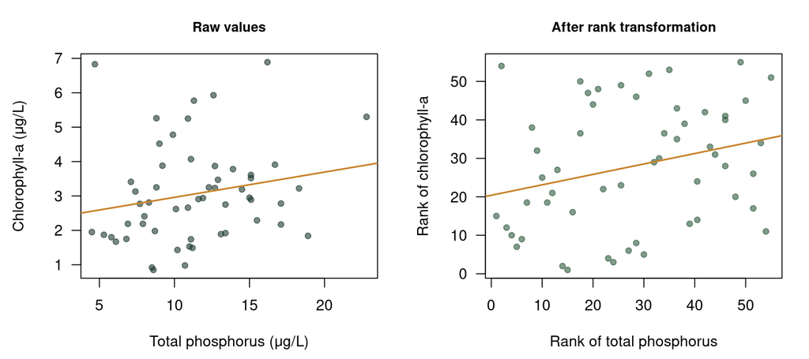

```r
par(mfrow = c(1,2), mar = c(4.5, 4.5, 3, 1.5), las = 1)

# Raw
plot(lakes$tp_ugl, lakes$chla,
     pch = 19, cex = 0.85, col = adjustcolor("#1e3a2f", 0.6),
     xlab = "Total phosphorus (μg/L)", ylab = "Chlorophyll-a (μg/L)",
     main = "Raw values", cex.main = 0.9)
abline(lm(chla ~ tp_ugl, data = lakes), col = "#c8832a", lwd = 1.8)

# Ranks
plot(rank(lakes$tp_ugl), rank(lakes$chla),
     pch = 19, cex = 0.85, col = adjustcolor("#2d5a3d", 0.6),
     xlab = "Rank of total phosphorus", ylab = "Rank of chlorophyll-a",
     main = "After rank transformation", cex.main = 0.9)
abline(lm(rank(chla) ~ rank(tp_ugl), data = lakes),
       col = "#c8832a", lwd = 1.8)
```

```r
par(mfrow = c(1,1))
```

```r
# Pearson on raw (underestimates due to non-linearity)
cor.test(lakes$tp_ugl, lakes$chla, method = "pearson")
```

```
##
##  Pearson's product-moment correlation
##
## data:  lakes$tp_ugl and lakes$chla
## t = 1.4989, df = 53, p-value = 0.1398
## alternative hypothesis: true correlation is not equal to 0
## 95 percent confidence interval:
##  -0.06722891  0.44324798
## sample estimates:
##       cor
## 0.2016651
```

```r
# Spearman on ranks (captures monotone relationship more faithfully)
cor.test(lakes$tp_ugl, lakes$chla, method = "spearman")
```

```
##
##  Spearman's rank correlation rho
##
## data:  lakes$tp_ugl and lakes$chla
## S = 20204, p-value = 0.04525
## alternative hypothesis: true rho is not equal to 0
## sample estimates:
##       rho
## 0.2711446
```

The contrast between the two outputs illustrates the core trade-off: Pearson’s r is attenuated by the non-linear scaling between TP and chl-a, while Spearman’s ρ captures the full monotone trend.

## 4. Pearson vs Spearman — Which to Use?

| Condition | Use |
| --- | --- |
| Both variables continuous and approximately normal | Pearson’s r |
| Non-normal distribution (heavy tails, skew) | Spearman’s ρ |
| Monotone but non-linear relationship | Spearman’s ρ |
| Ordinal variables (Likert scales, rankings) | Spearman’s ρ |
| Outliers present and non-removable | Spearman’s ρ |
| You need a confidence interval for ρ | Pearson (CI well-established); Spearman CI via bootstrap |
| Both normal + linear (large n) | Either; results converge |

**📌 The safe default strategy**

1. Plot the scatterplot.
2. Run Shapiro-Wilk on both variables.
3. If both pass and the plot looks linear → Pearson.
4. If either fails, or the plot bends → Spearman.
5. If results diverge substantially, report both and explain why.

For exploratory multi-variable work (correlation matrices), running Spearman throughout is a reasonable conservative default, especially with environmental data that often contain skewed chemistry variables.

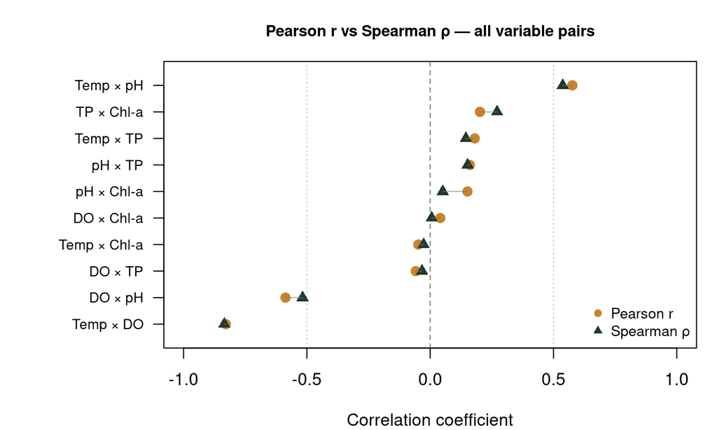

```r
vars   <- c("temp_C","do_mgl","pH","tp_ugl","chla")
labels <- c("Temp","DO","pH","TP","Chl-a")

pairs_idx <- combn(length(vars), 2)
r_pear <- apply(pairs_idx, 2, function(i)
  cor(lakes[, vars[i[1]]], lakes[, vars[i[2]]], method = "pearson"))
r_spear <- apply(pairs_idx, 2, function(i)
  cor(lakes[, vars[i[1]]], lakes[, vars[i[2]]], method = "spearman"))

pair_labels <- apply(pairs_idx, 2, function(i)
  paste(labels[i[1]], "×", labels[i[2]]))

ord <- order(r_pear)
par(mar = c(4, 8, 3, 1), las = 1)
y_pos <- seq_along(pair_labels)
plot(NA, xlim = c(-1, 1), ylim = c(0.5, length(pair_labels) + 0.5),
     xlab = "Correlation coefficient", ylab = "",
     main = "Pearson r vs Spearman ρ — all variable pairs",
     yaxt = "n", cex.main = 0.91)
abline(v = 0, lty = 2, col = "#7a7a72", lwd = 1)
abline(v = c(-0.5, 0.5), lty = 3, col = adjustcolor("#7a7a72", 0.4), lwd = 1)
axis(2, at = y_pos, labels = pair_labels[ord], cex.axis = 0.82)
points(r_pear[ord],  y_pos, pch = 19, col = "#c8832a", cex = 1.2)
points(r_spear[ord], y_pos, pch = 17, col = "#1e3a2f", cex = 1.2)
segments(r_pear[ord], y_pos, r_spear[ord], y_pos,
         col = adjustcolor("#7a7a72", 0.5), lwd = 1.2)
legend("bottomright",
       legend = c("Pearson r", "Spearman ρ"),
       pch = c(19, 17), col = c("#c8832a", "#1e3a2f"),
       bty = "n", cex = 0.85)
```

## 5. Scatterplot Matrices

When a dataset contains several continuous variables, examining every pairwise scatterplot simultaneously is more informative than reading a table of numbers. A **scatterplot matrix** (pairs plot) places every variable on both rows and columns, filling each cell with the bivariate scatterplot.

### Base R `pairs()`

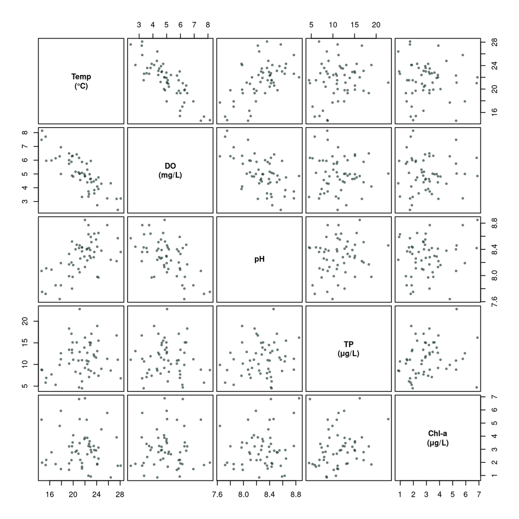

Base R pairs() matrix for the five lake chemistry variables. Each off-diagonal cell shows the scatterplot for that variable pair. Scan column-by-column or row-by-row to identify which pairs have strong linear or monotone relationships, which are non-linear, and which are independent.

```r
pairs(lakes,
      labels  = c("Temp\n(°C)", "DO\n(mg/L)", "pH", "TP\n(μg/L)", "Chl-a\n(μg/L)"),
      pch     = 19,
      cex     = 0.55,
      col     = adjustcolor("#1e3a2f", 0.55),
      gap     = 0.4,
      cex.labels = 1.0,
      font.labels = 2)
```

### Enhanced pairs panel with r values and smooths

Adding the correlation coefficient directly to each panel and a loess smooth makes the matrix far more informative for exploratory work.

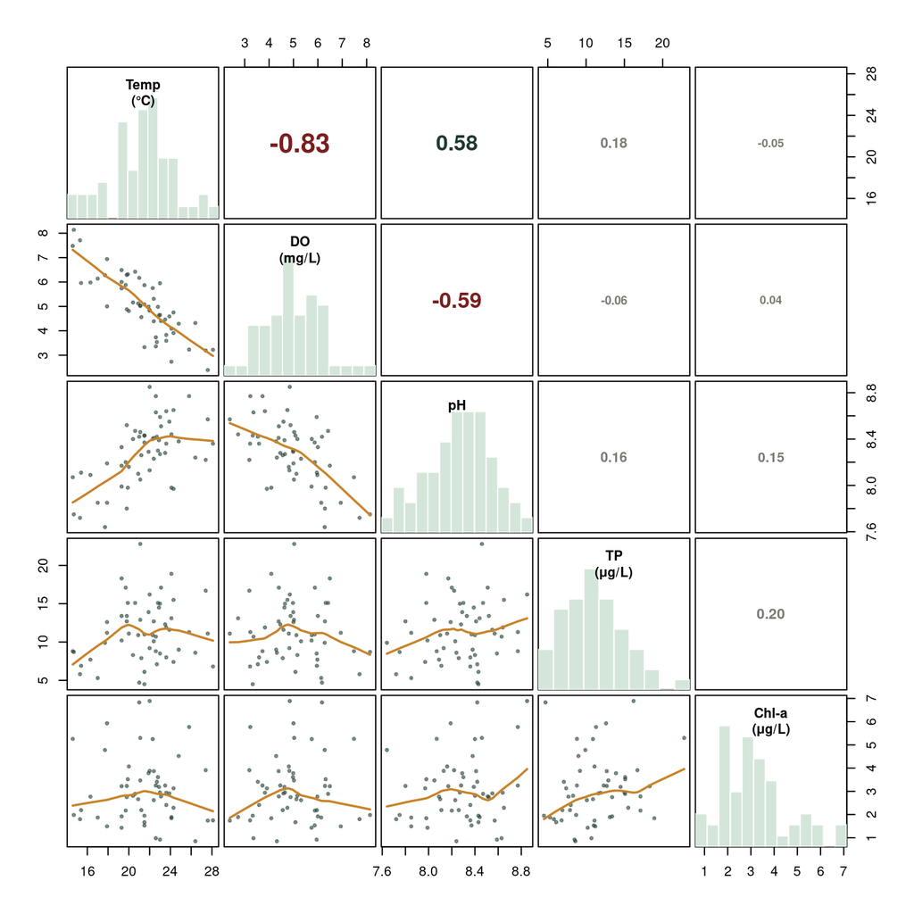

Enhanced scatterplot matrix with Pearson r in the upper triangle, loess smooths (amber) in the lower triangle, and variable histograms on the diagonal. The upper-triangle values are colour-coded: dark green = strong positive, red = strong negative, grey ≈ zero. Note the skewed distributions of TP and chl-a on the diagonal, reinforcing the case for Spearman correlation with those variables.

```r
# ── Panel functions ────────────────────────────────────────────────────────
panel_scatter <- function(x, y, ...) {
  points(x, y, pch = 19, cex = 0.5,
         col = adjustcolor("#1e3a2f", 0.5))
  ok <- is.finite(x) & is.finite(y)
  if (sum(ok) > 4)
    lines(lowess(x[ok], y[ok]), col = "#c8832a", lwd = 1.8)
}

panel_r <- function(x, y, ...) {
  usr <- par("usr"); on.exit(par(usr))
  par(usr = c(0, 1, 0, 1))
  r   <- cor(x, y, use = "pairwise.complete.obs")
  cex_r <- 0.8 + 1.4 * abs(r)
  col_r <- if (r > 0.5)  "#1e3a2f" else
            if (r < -0.5) "#7a1e1e" else "#7a7a72"
  text(0.5, 0.5, sprintf("%.2f", r),
       cex = cex_r, col = col_r, font = 2)
}

panel_hist <- function(x, ...) {
  usr <- par("usr"); on.exit(par(usr))
  h   <- hist(x, plot = FALSE, breaks = 10)
  breaks <- h$breaks
  par(usr = c(breaks[1], tail(breaks,1), 0, max(h$counts) * 1.25))
  rect(breaks[-length(breaks)], 0, breaks[-1], h$counts,
       col = "#d4e6da", border = "white")
}

pairs(lakes,
      labels      = c("Temp\n(°C)", "DO\n(mg/L)", "pH", "TP\n(μg/L)", "Chl-a\n(μg/L)"),
      lower.panel = panel_scatter,
      upper.panel = panel_r,
      diag.panel  = panel_hist,
      gap         = 0.35,
      cex.labels  = 1.0,
      font.labels = 2)
```

### The correlation matrix in numbers

```r
# Pearson correlation matrix — rounded
round(cor(lakes, method = "pearson"), 3)
```

```
##        temp_C do_mgl     pH tp_ugl   chla
## temp_C  1.000 -0.829  0.577  0.181 -0.048
## do_mgl -0.829  1.000 -0.587 -0.058  0.041
## pH      0.577 -0.587  1.000  0.161  0.151
## tp_ugl  0.181 -0.058  0.161  1.000  0.202
## chla   -0.048  0.041  0.151  0.202  1.000
```

```r
# Spearman correlation matrix — better for skewed variables
round(cor(lakes, method = "spearman"), 3)
```

```
##        temp_C do_mgl     pH tp_ugl   chla
## temp_C  1.000 -0.835  0.538  0.145 -0.027
## do_mgl -0.835  1.000 -0.518 -0.033  0.006
## pH      0.538 -0.518  1.000  0.152  0.051
## tp_ugl  0.145 -0.033  0.152  1.000  0.271
## chla   -0.027  0.006  0.051  0.271  1.000
```

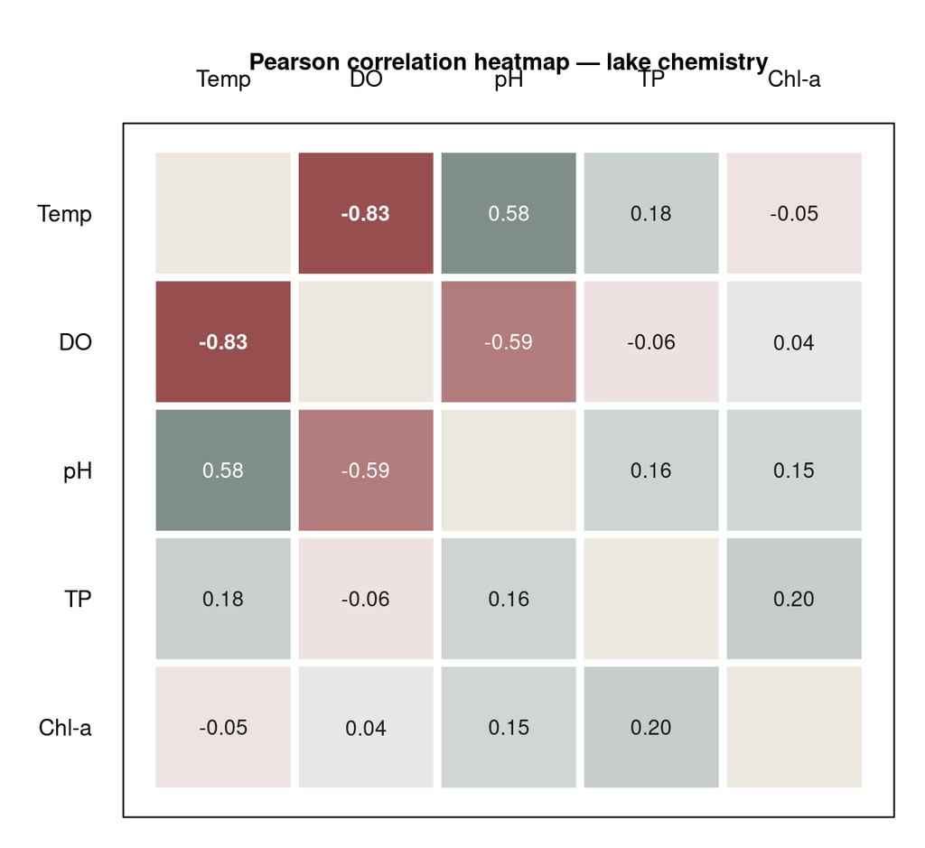

```r
R_mat <- cor(lakes, method = "pearson")
vars_lab <- c("Temp", "DO", "pH", "TP", "Chl-a")
p  <- nrow(R_mat)

# Colour mapping
r_to_col <- function(r) {
  if (r > 0) adjustcolor("#1e3a2f", alpha.f = abs(r) * 0.85 + 0.08)
  else       adjustcolor("#7a1e1e", alpha.f = abs(r) * 0.85 + 0.08)
}

par(mar = c(1, 4, 4, 1))
plot(NA, xlim = c(0.5, p + 0.5), ylim = c(0.5, p + 0.5),
     xaxt = "n", yaxt = "n", xlab = "", ylab = "",
     main = "Pearson correlation heatmap — lake chemistry",
     cex.main = 0.91)

for (i in seq_len(p)) {
  for (j in seq_len(p)) {
    r_ij <- R_mat[i, j]
    rect(j - 0.48, p - i + 0.52, j + 0.48, p - i + 1.48,
         col    = if (i == j) "#ede8df" else r_to_col(r_ij),
         border = "white", lwd = 1.5)
    if (i != j) {
      text(j, p - i + 1, sprintf("%.2f", r_ij),
           cex = 0.82, col = if (abs(r_ij) > 0.5) "#fff" else "#1a1a18",
           font = if (abs(r_ij) > 0.6) 2 else 1)
    }
  }
}
axis(3, at = seq_len(p), labels = vars_lab, tick = FALSE, cex.axis = 0.88)
axis(2, at = seq_len(p), labels = rev(vars_lab), tick = FALSE,
     cex.axis = 0.88, las = 1)
```

## 6. Interpreting Correlation Structure

A scatterplot matrix reveals structure that individual pair-wise tests cannot — clusters of co-varying variables, redundancy, suppressor effects, and indirect associations driven by a shared third variable.

### Redundancy and multicollinearity

Variables with |r| > 0.8 are near-redundant: they carry almost the same information. In a regression context this is **multicollinearity**, which inflates coefficient standard errors. In an exploratory context it tells you that the two variables may be proxies for the same underlying process.

```r
# Which pairs are strongly correlated (|r| > 0.5)?
R_spear <- cor(lakes, method = "spearman")
strong  <- which(abs(R_spear) > 0.5 & upper.tri(R_spear), arr.ind = TRUE)
data.frame(
  var1 = vars_lab[strong[,1]],
  var2 = vars_lab[strong[,2]],
  rho  = round(R_spear[strong], 3)
)
```

```
##   var1 var2    rho
## 1 Temp   DO -0.835
## 2 Temp   pH  0.538
## 3   DO   pH -0.518
```

### Spurious correlation via a shared driver

**Partial correlation** removes the linear effect of the confounding variable:

```r
# Partial correlation: pH ~ DO after removing shared variance with temperature
# Residualise both variables on temperature, then correlate residuals

res_pH <- residuals(lm(pH     ~ temp_C, data = lakes))
res_do <- residuals(lm(do_mgl ~ temp_C, data = lakes))

r_partial <- cor.test(res_pH, res_do, method = "pearson")
cat(sprintf(
  "Raw Pearson r(pH, DO)       = %.3f\n",
  cor(lakes$pH, lakes$do_mgl)
))
```

```
## Raw Pearson r(pH, DO)       = -0.587
```

```r
cat(sprintf(
  "Partial r(pH, DO | temp)    = %.3f  (p = %.3f)\n",
  r_partial$estimate,
  r_partial$p.value
))
```

```
## Partial r(pH, DO | temp)    = -0.239  (p = 0.079)
```

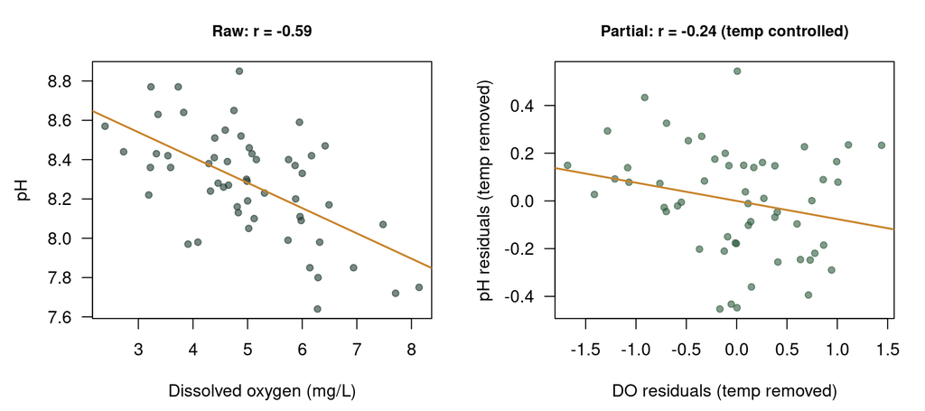

```r
par(mfrow = c(1,2), mar = c(4.5, 4.5, 3, 1.5), las = 1)

plot(lakes$do_mgl, lakes$pH,
     pch = 19, cex = 0.85, col = adjustcolor("#1e3a2f", 0.6),
     xlab = "Dissolved oxygen (mg/L)", ylab = "pH",
     main = sprintf("Raw: r = %.2f", cor(lakes$do_mgl, lakes$pH)),
     cex.main = 0.9)
abline(lm(pH ~ do_mgl, data = lakes), col = "#c8832a", lwd = 1.8)

plot(res_do, res_pH,
     pch = 19, cex = 0.85, col = adjustcolor("#2d5a3d", 0.6),
     xlab = "DO residuals (temp removed)", ylab = "pH residuals (temp removed)",
     main = sprintf("Partial: r = %.2f (temp controlled)",
                    r_partial$estimate),
     cex.main = 0.9)
abline(lm(res_pH ~ res_do), col = "#c8832a", lwd = 1.8)
```

```r
par(mfrow = c(1,1))
```

### Multiple testing in correlation matrices

A 5-variable matrix has $\binom{5}{2} = 10$ unique pairs; a 10-variable matrix has 45. Testing all pairs at α = 0.05 produces approximately $0.05 \times 10 = 0.5$ false positives per matrix by chance alone — nearly one spurious significant result for every two matrices examined.

```r
# Adjust p-values for multiple comparisons (Holm method)
p_mat <- matrix(NA, p, p, dimnames = list(vars_lab, vars_lab))
for (i in 1:(p-1)) for (j in (i+1):p) {
  p_mat[i,j] <- cor.test(lakes[[i]], lakes[[j]],
                           method = "pearson")$p.value
}

raw_p  <- p_mat[upper.tri(p_mat)]
adj_p  <- p.adjust(raw_p, method = "holm")

result_df <- data.frame(
  pair    = apply(combn(vars_lab, 2), 2, paste, collapse = " × "),
  r       = round(cor(lakes, method = "pearson")[upper.tri(R_mat)], 3),
  p_raw   = round(raw_p, 4),
  p_holm  = round(adj_p, 4),
  sig_raw = ifelse(raw_p  < 0.05, "✓", ""),
  sig_adj = ifelse(adj_p  < 0.05, "✓", "")
)
result_df
```

[output not shown]

**⚠️ Report adjusted p-values for correlation matrices**

When testing more than two pairs, use `p.adjust(p_vec, method = "holm")` and report both raw and adjusted values. Alternatively, treat the full matrix as **exploratory** — no p-values, just effect sizes — and reserve inferential testing for the one or two hypotheses specified in advance.

## 7. Common Misconceptions

Myth 1

“r = 0 means the two variables are unrelated.”

**Reality:** r = 0 means no *linear* relationship. A perfect quadratic (U-shaped) relationship yields r = 0. Always plot. Spearman’s ρ will also equal zero for a symmetric non-monotone curve, so neither coefficient detects all forms of dependence.

Myth 2

“A significant correlation proves causation.”

**Reality:** Correlation is symmetric and requires no causal structure. Ice-cream sales correlate positively with drowning deaths — both respond to summer heat. Causation requires temporal ordering, a plausible mechanism, and ideally experimental manipulation or a careful quasi-experimental design.

Myth 3

“r = 0.3 is a weak, unimportant correlation.”

**Reality:** Cohen’s benchmarks (0.10 / 0.30 / 0.50) are domain-agnostic conventions. In noisy environmental systems with many confounders, r = 0.30 can be scientifically meaningful and practically consequential. Effect size interpretation always requires disciplinary context, not just a universal benchmark.

Myth 4

“High r means the regression slope is steep.”

**Reality:** r measures tightness around the regression line, not slope. You can have r = 0.95 with a slope of 0.001 (tight but negligible effect per unit of x) or r = 0.60 with a slope of 50 (loose but large unit effect). The slope and r answer different questions.

Myth 5

“I can compare r values across studies with different sample sizes.”

**Reality:** r is a population-level parameter estimated from a sample. With small n, the sampling distribution of r is wide and skewed. Comparing r = 0.40 (n = 20) to r = 0.35 (n = 200) without accounting for sampling uncertainty is misleading. Use confidence intervals (Fisher z CI) and meta-analytic methods when synthesising across studies.

Myth 6

“Spearman ρ is just a fallback when Pearson fails.”

**Reality:** Spearman’s ρ is a full-fledged measure of monotone association with its own interpretation. For ordinal data or whenever the question is about rank ordering (e.g., “do species rank similarly in abundance across two sites?”), Spearman is the *correct* choice, not a fallback. It is not inferior — it answers a slightly different question.

## 8. Reporting Guidelines

A complete correlation report includes four components: the coefficient, degrees of freedom, p-value, and confidence interval. For matrices, effect sizes and adjusted p-values take priority over bare asterisks.

```r
# Full report for one pair
out <- cor.test(lakes$temp_C, lakes$do_mgl, method = "pearson")

cat(sprintf(
"Pearson's r(%d) = %.3f, 95%% CI [%.3f, %.3f], p %s\n",
  out$parameter,
  out$estimate,
  out$conf.int[1],
  out$conf.int[2],
  ifelse(out$p.value < 0.001, "< 0.001",
         sprintf("= %.3f", out$p.value))
))
```

```
## Pearson's r(53) = -0.829, 95% CI [-0.897, -0.722], p < 0.001
```

**💡 Prose template**

### Checklist before submitting a correlation analysis

| Check | Why |
| --- | --- |
| Scatterplot of every reported pair | Detect non-linearity, outliers, heteroscedasticity |
| Shapiro-Wilk (or QQ plot) on each variable | Choose Pearson vs Spearman |
| Report r *and* CI, not just p-value | p shrinks with n; r doesn’t |
| Adjust p-values if testing > 2 pairs | Multiple comparisons inflate false positives |
| State the method (Pearson / Spearman) | Readers cannot reproduce without this |
| Partial correlations if a confound is suspected | Raw r conflates direct and indirect paths |

#### 🔑 Correlation analysis — key takeaways

- **Plot first, always.** r and ρ are summaries of scatterplots. A non-linear, fan-shaped, or outlier-dominated cloud can produce any value of r; the number alone is uninterpretable without the picture.
- **Pearson r measures linearity; Spearman ρ measures monotonicity.** They answer slightly different questions. Use Pearson when both variables are approximately normal and the scatterplot looks linear. Use Spearman otherwise — it is not a fallback but a distinct and valid choice.
- **r = 0 does not mean independence.** Non-linear and non-monotone relationships are invisible to both coefficients. Only a scatterplot reveals them.
- **Scatterplot matrices reveal structure that tables cannot.** Redundant variables, indirect associations, and outlier-driven correlations are visible at a glance in a pairs plot. Build the matrix before reporting individual r values.
- **Adjust for multiple comparisons.** A correlation matrix with k variables has k(k−1)/2 pairs. Use

  ```
  p.adjust(p_vec, method =
  “holm”)
  ```

  or treat exploratory matrices as hypothesis-generating, not confirmatory.
- **Partial correlations reveal confounding.** A strong raw r between X and Y can vanish — or reverse — once a shared driver Z is controlled. Always ask: is there a third variable that both X and Y respond to?
- **Report the confidence interval, not just the p-value.** With n = 10, r = 0.60 has a 95% CI of [0.00, 0.90] — effectively uninformative. The CI communicates what the study was able to pin down.

### What’s next?

- **Simple Linear Regression** — when X causes Y and you need a slope, not just an r
- **Tests for Association** — chi-square and Fisher’s exact for categorical variables
- **Hypothesis Testing** — the five-step framework underlying `cor.test()`